# DATA 607 assignment 3A:Window Functions

Lionel jr. desroses

2026-09-20

## Introduction

For this assignment, I used a time-series dataset containing daily stock prices for two companies, AAPL and MSFT. The dataset includes a date column, a stock identifier, and a daily stock price.My approach was to organize the data chronologically and then apply window functions to calculate two metrics for each stock: Year-to-Date (YTD) Average,Six-Day Moving Average The YTD average provides a cumulative average from the beginning of the year through the current observation. The six-day moving average uses a rolling window consisting of the current day and the previous five days. These calculations help smooth fluctuations in stock prices and make trends easier to identify.

#Data

The dataset used in this analysis was a generated stock-price dataset containing 30 days of observations for two stocks, AAPL and MSFT. The data was stored in a CSV file and imported into R for analysis.

```r
library(readr)
stock_prices <- read_csv("https://raw.githubusercontent.com/lioneljr17/LDATA607/refs/heads/main/607LAB3B/stock_prices.csv", show_col_types = FALSE)
View(stock_prices)

head(stock_prices)
```

```
## # A tibble: 6 × 3
##   Date       Stock Price
##   <date>     <chr> <dbl>
## 1 2022-01-01 AAPL    170
## 2 2022-01-02 AAPL    172
## 3 2022-01-03 AAPL    171
## 4 2022-01-04 AAPL    174
## 5 2022-01-05 AAPL    176
## 6 2022-01-06 AAPL    175
```

## Calculating the YTD Average

In this section, I do the first window function, calculates a Year-to-Date average for each stock. This is a cumulative average that includes all observations from the beginning of the dataset through the current row.

```r
stocks_ytd <- stock_prices %>%
 group_by(Stock) %>%
 arrange(Date, .by_group = TRUE) %>%
 mutate(
  YTD_Avg = cummean(Price)
 )
```

# Calculating the Six-Day Moving Average

in this section,I do the second window function, calculates a six-day moving average. For each observation, the calculation uses the current day’s price and the previous 5 days’ prices. As the window moves forward, the oldest value is dropped, and the newest value is added.

```r
stocks_final <- stocks_ytd %>%
 group_by(Stock) %>%
 mutate(
  Moving_Avg_6 =
   slide_dbl(
    Price,
    mean,
    .before = 5,
    .complete = FALSE
   )
 )
write_csv(stocks_final,"stock_final.csv")

head(stocks_final,15)
```

```
## # A tibble: 15 × 5
## # Groups:   Stock [1]
##    Date       Stock Price YTD_Avg Moving_Avg_6
##    <date>     <chr> <dbl>   <dbl>        <dbl>
##  1 2022-01-01 AAPL    170    170          170
##  2 2022-01-02 AAPL    172    171          171
##  3 2022-01-03 AAPL    171    171          171
##  4 2022-01-04 AAPL    174    172.         172.
##  5 2022-01-05 AAPL    176    173.         173.
##  6 2022-01-06 AAPL    175    173          173
##  7 2022-01-07 AAPL    178    174.         174.
##  8 2022-01-08 AAPL    180    174.         176.
##  9 2022-01-09 AAPL    179    175          177
## 10 2022-01-10 AAPL    182    176.         178.
## 11 2022-01-11 AAPL    184    176.         180.
## 12 2022-01-12 AAPL    183    177          181
## 13 2022-01-13 AAPL    185    178.         182.
## 14 2022-01-14 AAPL    187    178.         183.
## 15 2022-01-15 AAPL    186    179.         184.
```

## result

The Year-to-Date average provides a cumulative view of stock performance from the beginning of the year through each observation. As additional observations are added, the average becomes less sensitive to daily fluctuations.The six-day moving average uses a rolling window that contains the current observation and the previous five observations. This creates a smoother trend line by reducing the impact of short-term price changes.Both calculations were performed separately for each stock using window functions, ensuring that observations from different stocks were not combined.

# Visualization

The following graph compares the original stock prices with the Year-to-Date average and the six-day moving average for each stock. The moving average line is smoother than the original price line because it averages multiple observations together.

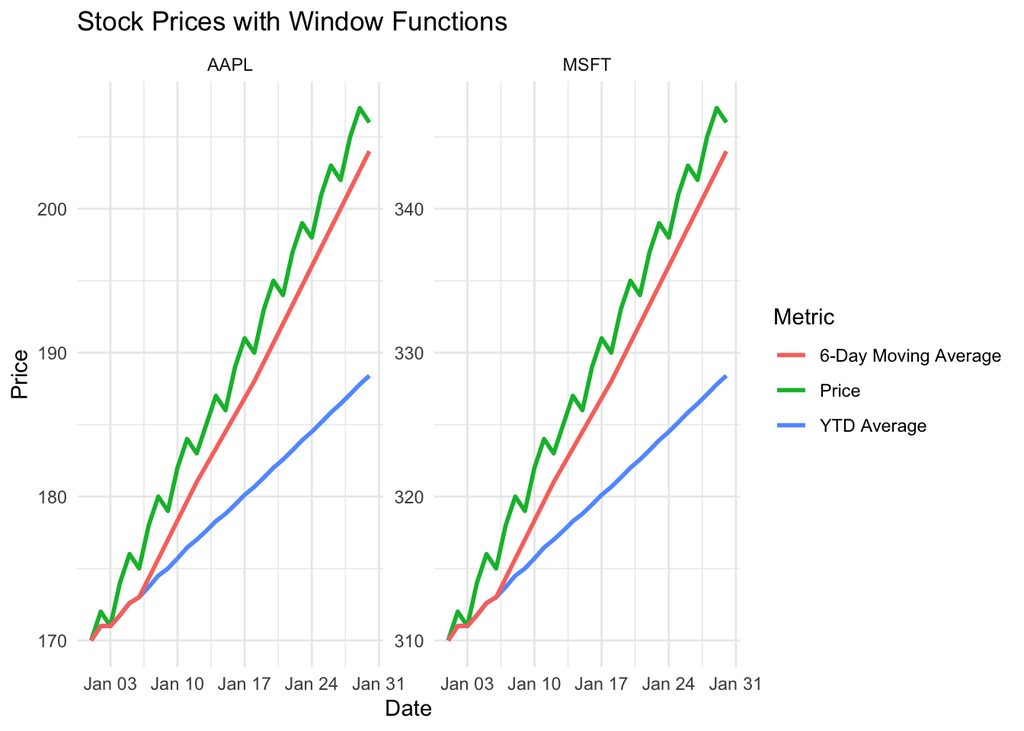

```r
ggplot(
 stocks_final,
 aes(x = Date)
) +
 geom_line(
  aes(y = Price,
    color = "Price"),
  linewidth = 1
 ) +
 geom_line(
  aes(y = YTD_Avg,
    color = "YTD Average"),
  linewidth = 1
 ) +
 geom_line(
  aes(y = Moving_Avg_6,
    color = "6-Day Moving Average"),
  linewidth = 1
 ) +
 facet_wrap(~Stock, scales = "free_y") +
 labs(
  title = "Stock Prices with Window Functions",
  x = "Date",
  y = "Price",
  color = "Metric"
 ) +
 theme_minimal()
```

## conclusion

This analysis demonstrated the use of window functions on time-series data. Using stock prices for AAPL and MSFT, I calculated both a Year-to-Date average and a six-day moving average. The YTD average provided a cumulative measure of performance throughout the year, while the six-day moving average highlighted short-term trends by smoothing daily fluctuations. These calculations illustrate how window functions can be used to analyze sequential data without collapsing the dataset through aggregation.